# Problem Set 2

### Step 5

```r
# Calculate beta manually
X <- matrix(c(rep(1, 4591),
              cars_df$eng_info_stats_hp,
              cars_df$eng_info_stats_tq,
              cars_df$dim_l,
              cars_df$dim_h,
              cars_df$dim_w,
              cars_df$category2009,
              cars_df$category2010,
              cars_df$category2011,
              cars_df$eng_info_stats_hp*cars_df$eng_info_stats_tq),
            nrow = 4591, ncol = 10)
y <- matrix(cars_df$fuel_info_hwy_mpg,
            nrow = 4591, ncol = 1)

beta <- solve(t(X)%*%X)%*%t(X)%*%y
beta
```

```
               [,1]
 [1,] 43.3849808673
 [2,] -0.0166633227
 [3,] -0.0860592704
 [4,]  0.0017767232
 [5,]  0.0065603903
 [6,] -0.0011694485
 [7,] -1.1970329986
 [8,] -1.7598187756
 [9,] -1.1244973555
[10,]  0.0001123567
```

It can be shown that the beta estimator generated manually is identical to the one using lm() function.

### Problem 3

### Step 1

Import the data and rename the columns.

Stata Input:

```stata
import delimited using "/Users/yipengliu/Desktop/Graduate Courses/STATS 506/Homework/Problem Set 2/cars.csv", clear

rename dimensionsheight dim_h
rename dimensionslength dim_l
rename dimensionswidth dim_w
rename engineinformationdriveline eng_info_dr
rename engineinformationenginetype eng_info_type
rename engineinformationhybrid eng_info_hbd
rename engineinformationnumberofforward eng_info_numgears
rename engineinformationtransmission eng_info_trans
rename fuelinformationcitympg fuel_info_city
rename fuelinformationfueltype fuel_info_type
rename fuelinformationhighwaympg fuel_info_hwy_mpg
rename identificationclassification iden_clf
rename identificationid iden_id
rename identificationmake iden_make
rename identificationmodelyear iden_mdyear
rename identificationyear iden_year
rename engineinformationenginestatistic eng_info_stats_hp
rename v18 eng_info_stats_tq
```

### Step 2

Restrict the data to cars whose Fuel Type is “Gasoline”.

Stata Input:

```stata
keep if fuel_info_type == "Gasoline"
```

Stata Output:

```
(485 observations deleted)

.
end of do-file
```

### Step 3

First, we transform the categorical variable into dummy variables, while avoiding multicollinearity in the subsequent regression analysis.

Stata Input:

```stata
tabulate iden_year, generate(dummy)
```

Stata Output:

```
Identificat |
   ion.Year |      Freq.     Percent        Cum.
------------+-----------------------------------
       2009 |         48        1.05        1.05
       2010 |      1,633       35.57       36.62
       2011 |      1,794       39.08       75.69
       2012 |      1,116       24.31      100.00
------------+-----------------------------------
      Total |      4,591      100.00

.
end of do-file
```

Then, fit the model.

Stata Input:

```stata
regress fuel_info_hwy_mpg eng_info_stats_hp eng_info_stats_tq dim_l dim_h dim_w dummy1 dummy2 dummy3
```

Stata Output:

```
      Source |       SS           df       MS      Number of obs   =     4,591
-------------+----------------------------------   F(8, 4582)      =    413.35
       Model |  70043.6695         8  8755.45869   Prob > F        =    0.0000
    Residual |   97055.298     4,582  21.1818634   R-squared       =    0.4192
-------------+----------------------------------   Adj R-squared   =    0.4182
       Total |  167098.968     4,590  36.4050038   Root MSE        =    4.6024

-------------------------------------------------------------------------------
fuel_info_h~g | Coefficient  Std. err.      t    P>|t|     [95% conf. interval]
--------------+----------------------------------------------------------------
eng_info_st~p |   .0163556   .0022772     7.18   0.000     .0118913      .02082
eng_info_st~q |  -.0507425    .002203   -23.03   0.000    -.0550614   -.0464236
        dim_l |    .001729   .0008836     1.96   0.050    -3.36e-06    .0034613
        dim_h |   .0099079   .0011267     8.79   0.000      .007699    .0121168
        dim_w |  -.0003343   .0009045    -0.37   0.712    -.0021075    .0014388
       dummy1 |  -1.302928   .6810076    -1.91   0.056    -2.638031    .0321751
       dummy2 |  -1.756896   .1795627    -9.78   0.000    -2.108925   -1.404867
       dummy3 |  -1.131826   .1765013    -6.41   0.000    -1.477854   -.7857987
        _cons |   33.59559   .3499147    96.01   0.000     32.90959    34.28159
-------------------------------------------------------------------------------
.
end of do-file
```

The estimated coefficient of the predictor “horsepower” is 0.0163556, which means that in the case where the car was measured in the same year, the car’s length, width, and height dimensions are all equal, and the torque of the engine are all equal, for every unit of horsepower that increases, the mpg on the highway increases by 0.0163556. This result is consistent with what we obtained in R.

### Step 4

First, refit the model including the interaction term.

Stata Input:

```stata
regress fuel_info_hwy_mpg c.eng_info_stats_hp##c.eng_info_stats_tq dim_l dim_h dim_w dummy1 dummy2 dummy3
```

Stata Output:

```
. regress fuel_info_hwy_mpg c.eng_info_stats_hp##c.eng_info_stats_tq dim_l dim_h dim_w du
> mmy1 dummy2 dummy3

      Source |       SS           df       MS      Number of obs   =     4,591
-------------+----------------------------------   F(9, 4581)      =    480.07
       Model |  81105.8715         9  9011.76351   Prob > F        =    0.0000
    Residual |   85993.096     4,581  18.7716865   R-squared       =    0.4854
-------------+----------------------------------   Adj R-squared   =    0.4844
       Total |  167098.968     4,590  36.4050038   Root MSE        =    4.3326

--------------------------------------------------------------------------------------
   fuel_info_hwy_mpg | Coefficient  Std. err.      t    P>|t|     [95% conf. interval]
---------------------+----------------------------------------------------------------
   eng_info_stats_hp |  -.0166633   .0025388    -6.56   0.000    -.0216406    -.011686
   eng_info_stats_tq |  -.0860593   .0025333   -33.97   0.000    -.0910257   -.0810928
 c.eng_info_stats_hp#|
 c.eng_info_stats_tq |   .0001124   4.63e-06    24.28   0.000     .0001033    .0001214
               dim_l |   .0017767   .0008318     2.14   0.033     .0001459    .0034075
               dim_h |   .0065604   .0010696     6.13   0.000     .0044634    .0086573
               dim_w |  -.0011694   .0008521    -1.37   0.170      -.00284    .0005011
              dummy1 |  -1.197033   .6411085    -1.87   0.062    -2.453915    .0598488
              dummy2 |  -1.759819   .1690386   -10.41   0.000    -2.091216   -1.428422
              dummy3 |  -1.124497   .1661568    -6.77   0.000    -1.450245   -.7987499
               _cons |   43.38498   .5206996    83.32   0.000     42.36416     44.4058
--------------------------------------------------------------------------------------
```

Then, plot the interaction plot.

Stata Input:

```stata
sum eng_info_stats_tq
margins, at(eng_info_stats_tq = (98(10)774) eng_info_stats_hp = (263, 267.5, 317) dummy1 = 1)
marginsplot
```

Stata Output:

```
. sum eng_info_stats_tq

    Variable |        Obs        Mean    Std. dev.       Min        Max
-------------+---------------------------------------------------------
eng_info_s~q |      4,591    267.2196    101.3269         98        774

. margins, at(eng_info_stats_tq = (98(10)774) eng_info_stats_hp = (263, 267.5, 317) dummy
> 1 = 1)

Predictive margins                                       Number of obs = 4,591
Model VCE: OLS

Expression: Linear prediction, predict()
1._at:   eng_info_stats~p =   263
         eng_info_stats~q =    98
         dummy1           =     1
2._at:   eng_info_stats~p =   263
         eng_info_stats~q =   108
         dummy1           =     1
3._at:   eng_info_stats~p =   263
         eng_info_stats~q =   118
         dummy1           =     1
4._at:   eng_info_stats~p =   263
         eng_info_stats~q =   128
         dummy1           =     1
5._at:   eng_info_stats~p =   263
         eng_info_stats~q =   138
         dummy1           =     1
6._at:   eng_info_stats~p =   263
         eng_info_stats~q =   148
         dummy1           =     1
7._at:   eng_info_stats~p =   263
         eng_info_stats~q =   158
         dummy1           =     1
8._at:   eng_info_stats~p =   263
         eng_info_stats~q =   168
         dummy1           =     1
9._at:   eng_info_stats~p =   263
         eng_info_stats~q =   178
         dummy1           =     1
```

[output cut: 793 more lines]

```
        203  |  -1.362629   1.118562    -1.22   0.223     -3.55555    .8302918
        204  |  -1.867051   1.135634    -1.64   0.100     -4.09344    .3593386
------------------------------------------------------------------------------

. marginsplot

Variables that uniquely identify margins: eng_info_stats_tq eng_info_stats_hp

.
end of do-file

. graph save "Graph" "/Users/yipengliu/Desktop/Graduate Courses/STATS 506/Homework/Proble
> m Set 2/Interaction Plot.gph"
file /Users/yipengliu/Desktop/Graduate Courses/STATS 506/Homework/Problem Set 2/Interacti
> on Plot.gph saved
```

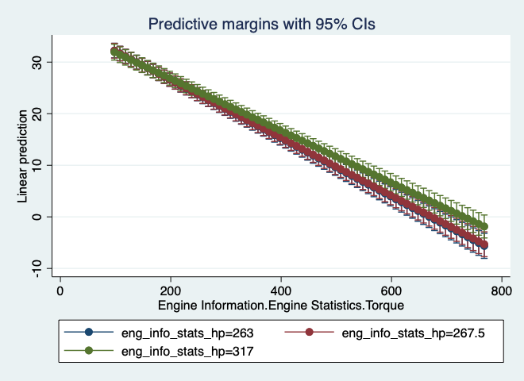

Interaction Plot